# Homework 2. Clustering

Mike

29 марта 2017 г

```r
library(DESeq2)
library(ggplot2)
library(pheatmap)
library(amap)
library(dbscan)
options(width=120)
```

# Intro

Чаще всего при работе с данными экспрессии используется две кластеризации: иерархическая кластеризация в пространстве образцов и K-means в пространстве генов.

Первая нужна для того, чтобы понимать как ваши образцы соотносятся с дизайном эксперимента, который у вас есть, а также для поиска аутлаеров в вашем эксперименте (ведь если есть образцы, которые совсем не похожи на другие, должно быть, это аутлаеры? Или нет?).

Вторая нужна для описания паттернов экспрессии в ваших образцах + приятнее рисовать хитмапы, когда гены идут не как попало, а упорядочены в кластеры.

В обоих случаях, мы будем использовать корреляцию (между образцами и между генами) как меру похожести для нашей кластеризации. И соотвественно 1 - cor(x, y) – как меру “непохожести”.

Также в обоих случаях, мы сначала оставим только 8000 самых сильно эспрессированных генов. Это делается за тем, что мало экспрессированные гены привносят шум в “паттерны” экспрессии, а так же невольно завышают корреляцию между образцами: ведь они слабо экспрессированы во всех образцах.

# Hierarchical clustering

Возьмем весь датасет с аутлаером

```r
counts <- read.csv("../data/GSE89225_Illumina_counts.csv", row.names=1)
conditions <- read.csv("../data/conditions.csv", row.names=1)
```

Создадим DeseqDataSet объект (дизайн не важен)

```r
dds <- DESeqDataSetFromMatrix(countData = counts,
                              colData = conditions,
                              design = ~ tissue + cells)
```

Оставим только 8000 экспрессированых генов

```r
dds <- dds[order(rowSums(counts(dds)), decreasing = T), ][1:8000, ]
dds <- DESeq(dds)
vst_dds <- vst(dds)
counts.norm <- assay(vst_dds)
```

Используем rlog(dds) для получения логарифмированных значений экспрессии

```r
log_dds <- rlog(dds)
counts.log <- assay(log_dds)
```

Посчитаем корреляции между образцами используя cor (результатом будет матрица размера m×m, где m – количество образцов)

```r
cor_log_dds <- cor(counts.log)
```

Посчитаем матрицу “непохожести” 1 - cor, и dist объект для этой матрицы

```r
cor_log_dds_rev <- 1 - cor_log_dds
dist_cor_rev <- dist(cor_log_dds_rev)
```

Сделаем кластеризацию с помощью функции hclust, используя три разных метода “связывания” объектов в группы: average, complete and single Построим для каждой график с помощью plot

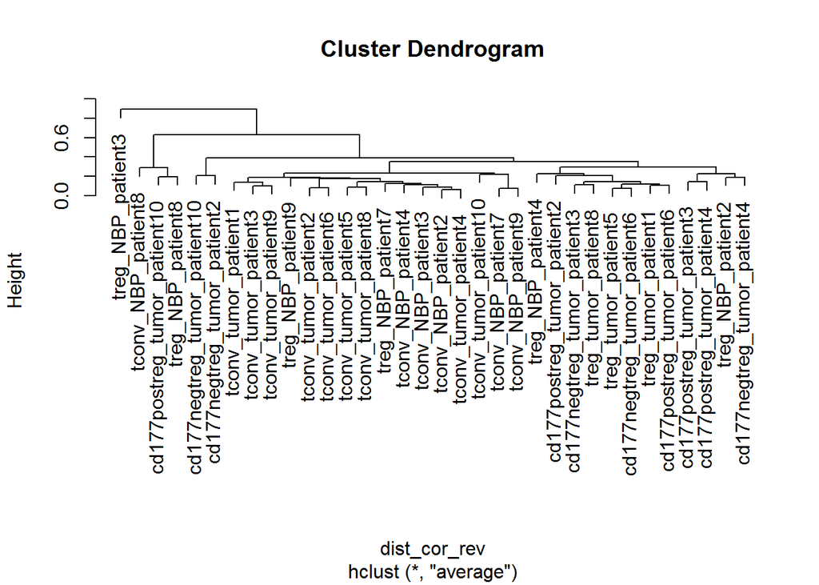

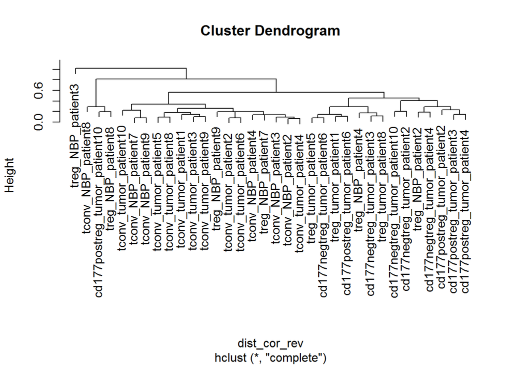

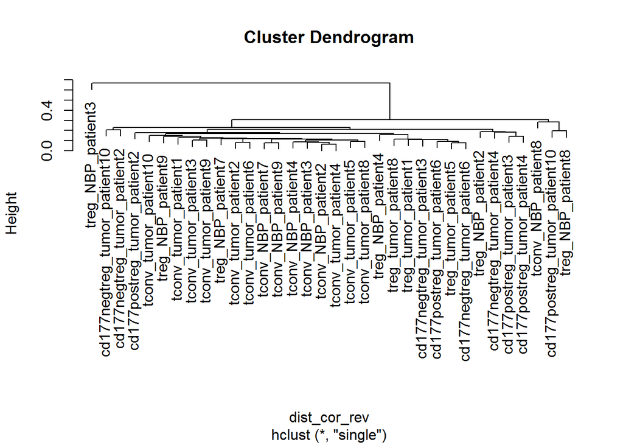

```r
ms <- c("average", "complete", "single")
lapply(ms, function(m) plot(hclust(dist_cor_rev, m)))
```

# K-means

Возьмем весь датасет без аутлаера

```r
counts <- counts[, colnames(counts) != "treg_NBP_patient3"]
conditions <- conditions[rownames(conditions) != "treg_NBP_patient3", ]
```

Создадим DeseqDataSet объект (дизайн не важен)

```r
dds <- DESeqDataSetFromMatrix(countData = counts,
                              colData = conditions,
                              design = ~ tissue + cells)
```

Оставим только 8000 экспрессированых генов

```r
dds <- dds[order(rowSums(counts(dds)), decreasing = T), ][1:8000, ]
dds <- DESeq(dds)
vst_dds <- vst(dds)
counts.norm <- assay(vst_dds)
```

Используем rlog(dds) для получения логарифмированных значений экспрессии

```r
log_dds <- rlog(dds)
counts.log <- assay(log_dds)
```

Используем функцию Kmeans из пакета amap с методом “correlation”, c количеством кластеров равным 6. (Вы можете выбрать своё количество кластеров), и максимальным количеством итераций равным 20000

```r
kms <- Kmeans(counts.log, method = "correlation", iter.max = 20000, centers = 6)
```

После этого вы можете достать соотвествие каждого гена кластеру с помощью элемента листа с названием “cluster”

```r
head(kms$cluster)
```

```
## ENSG00000166710 ENSG00000210082 ENSG00000251562 ENSG00000075624 ENSG00000198804 ENSG00000198938
##               2               1               5               2               6               6
```

После этого от вас потребуется эту кластеризацию изобразить на хитмапе: гены должны быть отсортированы по кластерам, а столбцы сначала по клеткам, а затем по тканям.

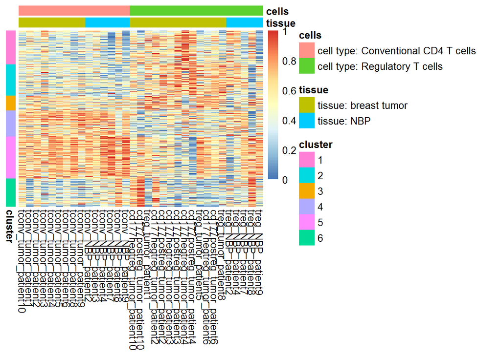

```r
to_visualise <- counts.log[order(kms$cluster), order(conditions$cells, conditions$tissue)]
to_visualise <- t(apply(to_visualise, 1, function(r) {
  (r - min(r)) / (max(r) - min(r))
}))

pheatmap(to_visualise,
         show_rownames = F, cluster_rows = F,
         cluster_cols=F,
         annotation_col = conditions,
         annotation_row = data.frame(cluster = as.factor(kms$cluster)))
```

# Density based algortihms

Есть алгоритмы, которые позволяют находить “плотные” кластеры, и при этом им не нужно указывать число кластеров. Пример такого алгоритма (DBSCAN) был на журнальном клубе посвящённому single-cell RNA-seq. В этом задании от вас потребуется запустить DBSCAN и подобрать к нему аргументы так, чтобы картинка была похожа на что-нибудь разумное.

В архиве находится файлик projection.csv, который содержит в себе результаты анализа данных single-cell RNA-seq, а именно tSNE-проекции всех клеток. По сути каждая клетка здесь определена в двух-мерном пространстве, и клетки транскрипционные профили которых бризки друг к другу находятся на этой проекции близко, а те, что транскрипционно различаются – находятся дальше.

Базовая концепция алгоритма DBSCAN очень простая – для каждой точки, мы можем посмотреть количество точек-соседей, которые находятся к ней ближе чем на какое-то расстояние ϵϵ. Если количество точек, в этой ϵϵ-окрестности больше или равно заранее определенного числа kk, и какие-то из этих точек-соседей уже лежат в кластере – то нашу точку можно в этот кластер добавить.

Пакет dbscan доступен из CRAN, функция dbscan принимает, кроме объекта с точками в пространстве, два аргумента: радиус окружности вокруг точки ϵϵ, в которой мы пытаемся найти достаточноe число соседей, и достаточно число соседей kk в этой окружности.

Ознакомиться с пакетом можно тут: https://cran.r-project.org/web/packages/dbscan/vignettes/dbscan.pdf , там же можно ознакомиться и с работой алгоритма и базовой простой концепцией.

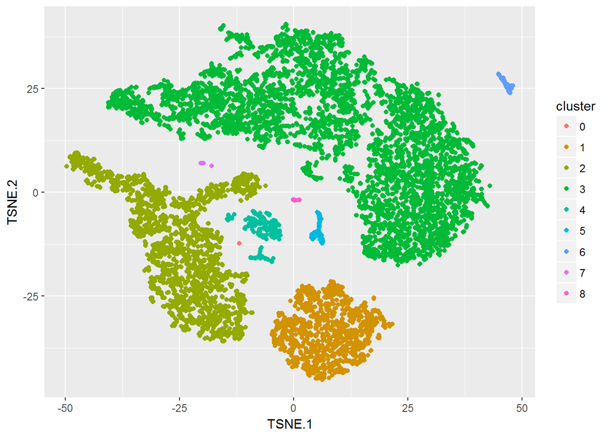

```r
projection <- read.csv("../data/projection.csv", stringsAsFactors = F)[, c(2,3)]
clustering <- dbscan(projection, eps = 3, minPts = 5)
projection$cluster <- as.factor(clustering$cluster)

ggplot(projection, aes(x = TSNE.1, y = TSNE.2, col = cluster))+
  geom_point()
```